# Data acquisition and processing: Demultiplex & quality trim reads

Central Valley Chinook Salmon

SJ O’Leary

2019-12-04

# Demultiplex sequence data

```bash
# extract single end reads from concatenated files and assign to correct sample based on barcode.
process_radtags -f $datadir/BMAG002conc.fastq -i fastq -y gzfastq -b BMAG002.barcodes -o . --renz_1 sbfI -E phred33 -r --bestrad
```

`process_radtags` used to demultiplex samples for each set of samples (per library), files were then renamed to include LIB_ID (Prefix `ONC_`). For each library extraction script is in the `SEQ` subdirectory, resulting log-files for each library moved to `SEQ`-directory to assess quality.

# Quality control demultiplexed reads

Parse process radtags log file.

Table : Comparison of total sequences and proportion of reads not retained due to barcodes and/or cut-sites not being found.

| Library | Total.Sequences | Retained.Reads | Proportion.retained | Proportion.No.Barcode | Proportion.No.Cutsite |
| --- | --- | --- | --- | --- | --- |
| BMAG001 | 460215599 | 304685527 | 0.662 | 0.245 | 0.093 |
| BMAG002 | 199147721 | 115571623 | 0.580 | 0.242 | 0.178 |
| BMAG006 | 261423258 | 118366958 | 0.453 | 0.367 | 0.180 |
| BMAG007 | 184951533 | 105465834 | 0.570 | 0.245 | 0.184 |
| BMAG008 | 190330828 | 119808627 | 0.629 | 0.227 | 0.143 |
| BMAG009 | 210675876 | 140491757 | 0.667 | 0.227 | 0.106 |
| BMAG010 | 242280464 | 130310630 | 0.538 | 0.264 | 0.198 |
| BMAG013 | 202565682 | 118152619 | 0.583 | 0.263 | 0.154 |
| BMAG017 | 136417117 | 59806681 | 0.438 | 0.372 | 0.190 |
| BMAG020 | 204911036 | 142466765 | 0.695 | 0.212 | 0.092 |
| BMAG021 | 237354396 | 123452498 | 0.520 | 0.303 | 0.177 |
| BMAG022 | 239795157 | 109072926 | 0.455 | 0.275 | 0.270 |
| BMAG023 | 220703449 | 97056011 | 0.440 | 0.284 | 0.276 |
| BMAG024 | 235293651 | 101483787 | 0.431 | 0.264 | 0.305 |
| BMAG025 | 218071047 | 87275783 | 0.400 | 0.306 | 0.293 |

Compare demultiplexed reads per library.

Distribution of total number of million reads per individuals and proportion of retained reads

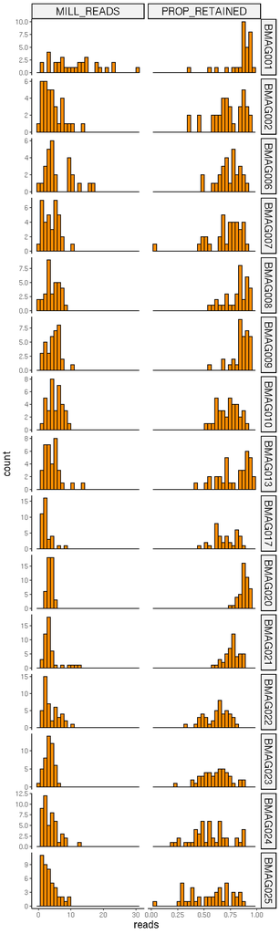

```r
read_delim("results/all.radtags.log", delim = "\t") %>%
  mutate(MILL_READS = TOTAL_READS/1000000) %>%
  select(LIBRARY, BARCODE, PROP_RETAINED, MILL_READS) %>%
  gather(key = STAT, value = READS, 3:4) %>%
  ggplot(aes(x = READS)) +
  geom_histogram(color = "black", fill = "darkorange") +
  labs(x = "reads") +
  facet_grid(LIBRARY ~ STAT, scales = "free") +
  theme_standard
```

# Quality trim

## Remove low quality individuals

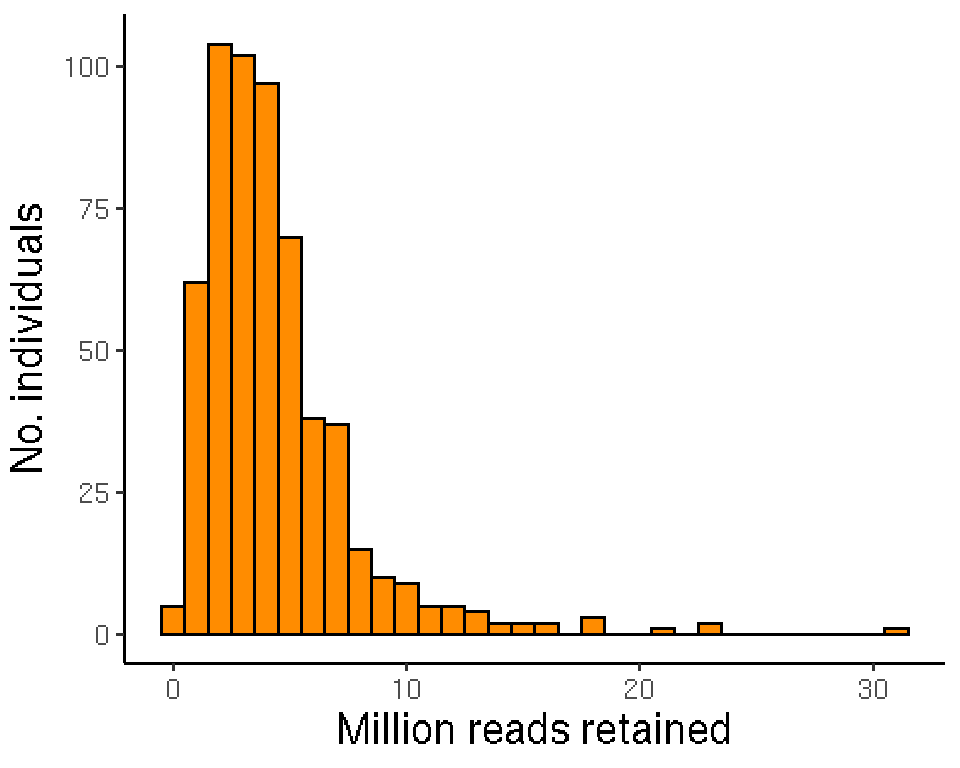

```r
read_delim("results/all.radtags.log", delim = "\t") %>%
  mutate(MILL_READS = TOTAL_READS/1000000) %>%
  ggplot(aes(x = MILL_READS)) +
  geom_histogram(binwidth = 1, color = "black", fill = "darkorange") +
  labs(x = "Million reads retained", y = "No. individuals") +
  theme_standard
```

```r
lq_ind <- read_delim("results/all.radtags.log", delim = "\t") %>%
  filter(RETAINED < 250000 | PROP_RETAINED < 0.25)
```

Write bash script to delete `fastq` files of low quality individuals from data set.

```r
seq_dir <- "$HOME/CHINOOK/data/SEQ/"

command <- "rm"

SEQ <- lq_ind %>%
  unite(FILE, LIBRARY, LIB_ID, sep = "/") %>%
  select(FILE) %>%
  mutate(temp = ".*",
         dir = seq_dir) %>%
  unite(SEQ, dir, FILE, temp, sep = "") %>%
  mutate(COMMAND = command) %>%
  select(COMMAND, SEQ)

write.table(SEQ, "scr/rm_LQind_ONC.sh",
            col.names = FALSE, quote = FALSE, row.names = FALSE)
```

Remove LQ individuals.

```bash
chmod 755 ./scr/rm_LQind_ONC.sh

./scr/rm_LQind_ONC.sh
```

## Quality trim data

PCR and sequencing can result in technical artifacts resulting in low quality reads. For example, Illumina sequences produce sequences of lower quality in later cycles resulting in low quality base calls on the 3’ end of sequences that need to be removed and partial adapter sequences may remain within the sequenced reads.

The `dDocent` pipeline wraps `fastp` (S. Chen et al. 2018) to quality trim reads and detect and remove remaining adapter sequences. Reads are trimmed using a sliding window approach where bases are dropped if the mean quality in a base drops below a set threshold value.

Chen, Shifu, Yanqing Zhou, Yaru Chen, and Jia Gu. 2018. “Fastp: An ultra-fast all-in-one FASTQ preprocessor.” In *Bioinformatics*, 34:i884–i890. 17. Narnia. doi:10.1093/bioinformatics/bty560.

**Parameters used:**

- `--cut_by_quality5` 20
- `--cut_by_quality3` 20
- `--cut_window_size` 5
- `--cut_mean_quality` 15
- `-q` 15
- `-u` 50

Run `dDocent` in each sequence folder to quality trim reads (use `SLURM` file to queue on hpcc).

```bash
# navigate to starting directory
cd $HOME/CHINOOK/data/SEQ/

for i in BMAG*; do

    cd cd $HOME/CHINOOK/data/SEQ/$i

    ## PREP FILES

    # copy of configuration file
    cp cd $HOME/CHINOOK/scr/trim.config .

    # load modules
    module purge
    module load Anaconda2/4.2.0

    ## RUN dDOCENT

    # open bioconda environment
    source activate /mnt/home/olearys1/bin/miniconda3/envs/ddocent_env

    # run dDocent to quality trim & map reads to reference genome
    dDocent trim_map.config

    # close bioconda environment
    source deactivate

done
```